# HW2

Kai Barclay

2026-07-27

# Homework 2

Let’s get our libraries set up first.

```r
library(igraph)
library(ggplot2)
library(ggraph)
set.seed(42)
```

Next, let’s get our data.

```r
dataGitLink='https://github.com/KaiFish/DACSS-690C-Homework/raw/main/hollywood.graphml'
actors=read_graph(dataGitLink,format='graphml')
summary(actors)
```

```
## IGRAPH 4f31dc0 UNW- 11 14 --
## + attr: wonOscar (v/n), color (v/c), name (v/c), id (v/c), weight (e/n)
```

## Central Measures and Hubs

We are going to calculate our nodes’ central measures…

```r
eigen=eigen_centrality (actors)$vector

close=closeness(actors,normalized=T)

betw=betweenness(actors,normalized=T)

DFCentrality=as.data.frame(cbind(eigen,close,betw),stringsAsFactors = F)
names(DFCentrality)=c('Eigenvector','Closeness','Betweenness')

DFCentrality$person=row.names(DFCentrality)
row.names(DFCentrality)=NULL
```

… and make a correlation plot of our results.

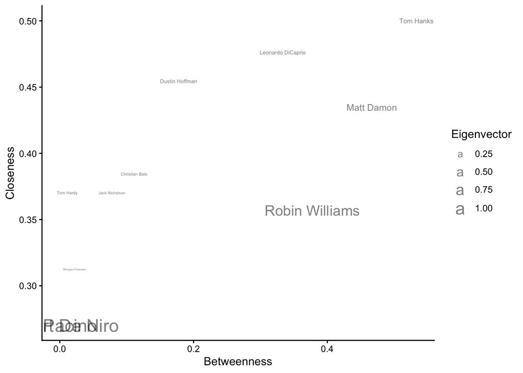

```r
ggplot(DFCentrality, aes(x=Betweenness, y=Closeness)) +
    theme_classic() +
    geom_text(aes(label=person,size=Eigenvector),show.legend = T,alpha=0.5)
```

We can see Robin Williams clearly, but there are two names that are overlapping and hard to read. To see those:

```r
HubNodes=dplyr::slice_max(DFCentrality, order_by = Eigenvector, n = 2)$person
HubNodes
```

```
## [1] "Al Pacino"      "Robert De Niro"
```

Al Pacino and Robert De Niro have been in multiple films together, unlike the other actors in this graph.

Let’s see our plot with our hub nodes highlighted:

```r
NodeCount=length(V(actors))

V(actors)$label=''

for (index in seq(1:NodeCount)){
    currentName=V(actors)$name[index]
    if (currentName%in%HubNodes){
            V(actors)$label[index]=currentName
    }
}

base=ggraph(graph = actors)
```

```
## Using "stress" as default layout
```

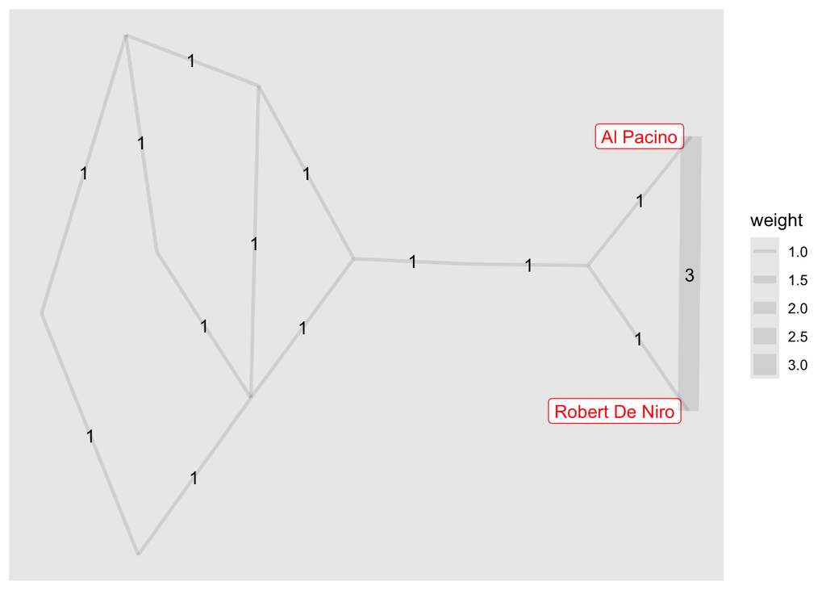

```r
base  + geom_node_label(aes(label = label),
                        repel = TRUE,
                        show.legend = F,
                        color='red') +
         geom_edge_link(alpha=0.1, aes(label=weight, edge_width=weight))
```

(De Niro and Pacino have now been in 4 films together, the most recent being *The Irishman* in 2019)

## Evaluate Possible Communities

Let’s calculate the possibility of community emergence. First, we need a distribution of a random network to calculate the mean random transitivity.

```r
set.seed(53)
# Generate an ensemble of 1000 rewired random networks
replicates <- 1000
random_transitivities <- replicate(replicates, {
  RandomNet <- rewire(actors,
                      keeping_degseq(niter = gsize(actors) * 10))
  transitivity(RandomNet, type = "global")
})
mean_random_transitivities=mean(random_transitivities)
```

Next, we will calculate the empirical transitivity we observe in our graph.

```r
# Calculate your empirical transitivity
empirical_transitivity <- transitivity(actors, type = "global")
```

Finally, we will calculate the ratio between our observed and random transitivities.

```r
report_table <- data.frame(
  Metric = c("Actors transitivity", "Random-network mean", "Ratio"),
  Value  = round(c(empirical_transitivity,
                    mean_random_transitivities,
                    empirical_transitivity / mean_random_transitivities), 4)
)
knitr::kable(report_table)
```

| Metric | Value |
| --- | --- |
| Actors transitivity | 0.2500 |
| Random-network mean | 0.1320 |
| Ratio | 1.8939 |

With a ratio greater than one, we may assess using our community-detection algorithms. We will use all five for comparison’s sake.

```r
# Run all five community-detection algorithms
algos <- list(
  louvain          =  { set.seed(123); cluster_louvain(actors) },
  walktrap         = cluster_walktrap(actors),
  fast_greedy      = cluster_fast_greedy(actors),
  infomap          = cluster_infomap(actors),
  edge_betweenness = cluster_edge_betweenness(actors)
)
# Build a summary table: number of clusters, modularity (Q), and cluster sizes
summary_table <- data.frame(
  algorithm   = names(algos),
  n_clusters  = sapply(algos, length),
  modularity_Q  = sapply(algos, modularity),
  cluster_sizes = sapply(algos, function(cl) {
    paste(sort(sizes(cl), decreasing = TRUE), collapse = ", ")
  })
)

# Sort by modularity, descending, so the "best" partition (by this metric) is on top
summary_table <- summary_table[order(-summary_table$modularity_Q), ]
rownames(summary_table) <- NULL

print(summary_table)
```

```
##          algorithm n_clusters modularity_Q cluster_sizes
## 1         walktrap          3    0.4199219       6, 3, 2
## 2          infomap          2    0.4199219          7, 4
## 3 edge_betweenness          2    0.4199219          7, 4
## 4          louvain          3    0.4121094       4, 4, 3
## 5      fast_greedy          3    0.4121094       4, 4, 3
```

All of the algorithms have a modularity above 0.4, indicating strong communities. Though all of the results were very close, we will use walktrap in the next section as it listed as our top result.

First, we will add our community ids as attributes for ease of use later.

```r
for (name in names(algos)) {
  memb <- membership(algos[[name]])
  attr_name <- name
  actors <- set_vertex_attr(actors, attr_name,
                               index = names(memb),
                              # this is important for exporting
                               value = as.vector(memb))
}
# verify new attributes
vertex_attr_names(actors)
```

```
##  [1] "wonOscar"         "color"            "name"             "id"
##  [5] "label"            "louvain"          "walktrap"         "fast_greedy"
##  [9] "infomap"          "edge_betweenness"
```

With that done, we can then use walktrap to graph our best result.

```r
base=ggraph(graph =actors) +
          geom_edge_link(alpha=0.2)
```

```
## Using "stress" as default layout
```

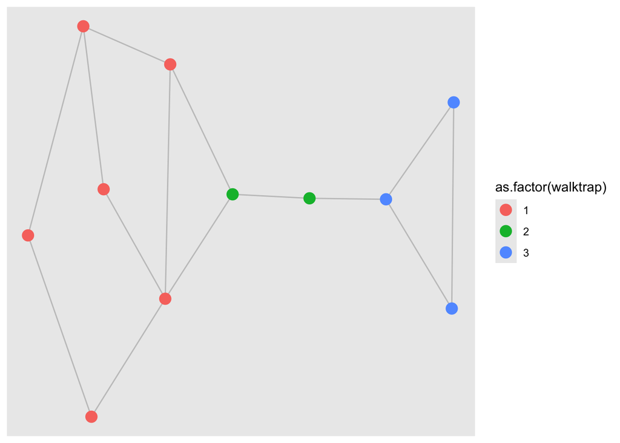

```r
base + geom_node_point(aes(color=as.factor(walktrap)),
                       show.legend = T, size=4)
```